# Patel_D_11

First we import the data set from an excel file

```r
library(openxlsx)
# Import the UFFI data into a data frame
uffi_data <- read.xlsx("uffidata.xlsx", sheet = 1, startRow = 1)
```

Lets take a look at the data and what variables it consists of

```r
head(uffi_data)
```

|  | Observation | Year.Sold | Sale.Price | UFFI.IN | Brick.Ext | 45.Yrs+ | Bsmnt.Fin_SF | Lot.Area | Enc.Pk.Spaces | Living.Area_SF | Central.Air | Pool |
| --- | --- | --- | --- | --- | --- | --- | --- | --- | --- | --- | --- | --- |
| 1 | 37 | 2009 | 76900 | 1 | 0 | 1 | 0.000 | 2772.0 | 0 | 1018.330 | 0 | 0 |
| 2 | 79 | 2009 | 78000 | 1 | 0 | 1 | 153.518 | 4490.0 | 0 | 536.203 | 1 | 0 |
| 3 | 75 | 2011 | 79000 | 0 | 0 | 1 | 400.000 | 5840.0 | 0 | 721.400 | 1 | 0 |
| 4 | 32 | 2011 | 80000 | 0 | 0 | 1 | 0.000 | 5040.0 | 0 | 512.504 | 0 | 0 |
| 5 | 69 | 2010 | 82000 | 1 | 0 | 1 | 157.080 | 5440.8 | 0 | 671.680 | 0 | 0 |
| 6 | 4 | 2011 | 84000 | 1 | 0 | 1 | 398.450 | 4800.0 | 1 | 449.450 | 0 | 0 |

We are looking for outliers in the data set, however what variables should we focus on? Outlier Assessment Method: 1. Look at numerical, non-binary values 2. Boxplot the values and find values outside of the Interquartile Range (IQR) 3. Compare Spearman rank and Pearson correlation of the values in the column and if they are close then keep the outliers, if not exclude the outliers (Assign them as the median value in the data)

```r
# First we evaluate the Observation variable
obs_box <- boxplot(uffi_data$Observation, plot=FALSE)$out
head(uffi_data[uffi_data$Observation %in% obs_box], 1)
```

| 1 |
| --- |

There are no outliers so no action is needed for the Observation variable

```r
# Evaluate the Sale.Price variable
price_box <- boxplot(uffi_data$Sale.Price, plot=FALSE)$out
price_outliers <- uffi_data[which(uffi_data$Sale.Price %in% price_box),]
price_outliers
```

|  | Observation | Year.Sold | Sale.Price | UFFI.IN | Brick.Ext | 45.Yrs+ | Bsmnt.Fin_SF | Lot.Area | Enc.Pk.Spaces | Living.Area_SF | Central.Air | Pool |
| --- | --- | --- | --- | --- | --- | --- | --- | --- | --- | --- | --- | --- |
| 91 | 95 | 2015 | 187000 | 0 | 0 | 0 | 719.80 | 7475.000 | 2 | 1343.300 | 1 | 0 |
| 92 | 19 | 2015 | 187500 | 1 | 0 | 1 | 719.60 | 8250.000 | 2 | 1535.600 | 1 | 0 |
| 93 | 97 | 2016 | 189000 | 0 | 1 | 0 | 153.51 | 10080.000 | 2 | 1320.950 | 1 | 0 |
| 94 | 22 | 2016 | 198000 | 0 | 0 | 1 | 308.64 | 6518.013 | 1 | 1350.217 | 1 | 0 |
| 95 | 21 | 2016 | 200000 | 0 | 0 | 1 | 260.40 | 5544.000 | 2 | 1792.630 | 0 | 1 |
| 96 | 71 | 2016 | 200000 | 0 | 1 | 1 | 213.76 | 4180.000 | 1 | 1576.390 | 1 | 0 |
| 97 | 94 | 2016 | 347000 | 0 | 1 | 0 | 441.50 | 8190.000 | 2 | 1279.690 | 1 | 1 |
| 98 | 40 | 2016 | 250000 | 0 | 1 | 1 | 0.00 | 11200.000 | 2 | 2338.657 | 1 | 0 |
| 99 | 60 | 2010 | 250000 | 1 | 1 | 1 | 0.00 | 11200.000 | 2 | 2042.947 | 1 | 0 |

There are outpliers so we apply step 3 for our outlier assessment method

```r
# WARNING: Running the cell twice before running cell with line 10 will give an error
price_orig <- uffi_data$Sale.Price
uffi_data$Sale.Price[uffi_data$Sale.Price %in% price_box] <- median(price_orig)
```

```r
cor(uffi_data$Sale.Price, price_orig)
```

```
[1] 0.5103028
```

Removing outliers will effect the data so we will keep them in the dataset

```r
uffi_data$Sale.Price <-price_orig
```

```r
# Evaluate the Bsmnt.Fin_SF variable
bsmt_box <- boxplot(uffi_data$Bsmnt.Fin_SF, plot=FALSE)$out
bsmt_outliers <- uffi_data[which(uffi_data$SBsmnt.Fin_SF %in% bsmt_box),]$Bsmnt.Fin_SF
bsmt_outliers
```

There are no outliers for the Bsmnt.Fin_SF variable

```r
# Evaluate the Lot.Area variable
area_box <- boxplot(uffi_data$Lot.Area, plot=FALSE)$out
area_outliers <- uffi_data[which(uffi_data$Lot.Area %in% area_box),]$Lot.Area
area_outliers
```

```
[1] 10000.00 11325.00 11650.26 10080.00 11200.00 11200.00
```

There are outpliers so we apply step 3 for our outlier assessment method

```r
# WARNING: Running the cell twice before running cell with line 10 will give an error
area_orig <- uffi_data$Lot.Area
uffi_data$Lot.Area[uffi_data$Lot.Area %in% area_box] <- median(area_orig)
```

```r
cor(uffi_data$Lot.Area, area_orig)
```

```
[1] 0.7402079
```

Removing outliers doesn’t effect the data (Correlation constant is close to 1) so we will remove them (already done above)

```r
# Evaluate the Living.Area_SF variable
live_box <- boxplot(uffi_data$Living.Area_SF, plot=FALSE)$out
live_outliers <- uffi_data[which(uffi_data$Living.Area_SF %in% live_box),]$Living.Area_SF
live_outliers
```

```
[1] 1792.630 2338.657 2042.947
```

There are outliers so we apply step 3 for our outlier assessment method

```r
# WARNING: Running the cell twice before running cell with line 10 will give an error
live_orig <- uffi_data$Living.Area_SF
uffi_data$Living.Area_SF[uffi_data$Living.Area_SF %in% live_box] <- median(live_orig)
```

```r
cor(uffi_data$Living.Area_SF, live_orig)
```

```
[1] 0.7377281
```

Removing outliers doesn’t effect the data (Correlation constant is close to 1) so we will remove them (already done above)

2. Using visual analysis of the sales price with a histogram, is the data normally distributed and thus amenable to parametric statistical analysis?

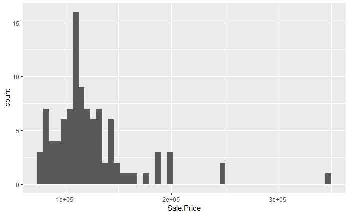

```r
library(ggplot2)
ggplot(data = uffi_data,
       mapping = aes(x = Sale.Price)) + geom_histogram(bins=50)
```

```r
summary(uffi_data$Sale.Price)
```

```
   Min. 1st Qu.  Median    Mean 3rd Qu.    Max.
  76900  102000  115000  124450  135000  347000
```

```r
shapiro.test(uffi_data$Sale.Price)
```

```
    Shapiro-Wilk normality test

data:  uffi_data$Sale.Price
W = 0.78312, p-value = 8.957e-11
```

**The data is skewed right and is not normally distributed**

3. Using a z-test, is the presence or absence of UFFI alone enough to predict the value of a residential property? Method:
4. We will do a two-sample z-test on the populations of houses with and without UFFI
5. The Z-Score will determine if there is a significant difference between the two populations and each other and th full dataset our alpha is 0.05 so if the z-score is beyond +- 1.96 there is a significant difference
6. Make a determination on the price based on the results

```r
# Calculates the proper variance with length (n)
var.p <- function(x){var(x)*(length(x)-1)/length(x)}
two_samp_z <- function(x, y){
  # Calculates the z-score
  #
  # Args:
  # x- first sample
  # y- second sample
  #
  # Returns:
  # Z-score for the two sample z-test of x and y
   n.x <- length(x)
   n.y <- length(y)
   z <- (mean(x) - mean(y)) / (sqrt(var.p(x)/n.x + var.p(y)/n.y))
   return(z)
}
```

```r
# Obtain the two populations
with_uffi <- uffi_data$Sale.Price[uffi_data$UFFI.IN == 1]
without_uffi <- uffi_data$Sale.Price[uffi_data$UFFI.IN == 0]
# Run the Z-tests
two_samp_z(with_uffi, without_uffi)
```

```
[1] -1.343718
```

```r
two_samp_z(with_uffi, uffi_data$Sale.Price)
```

```
[1] -1.060733
```

```r
two_samp_z(without_uffi, uffi_data$Sale.Price)
```

```
[1] 0.4784674
```

The presence or absence of uffi is not enough to predict the value of the residential property

4. Is UFFI a significant predictor variable of selling price when taken with the full set of variables available? We will do an ANOVA of the sales price data between groups (Had UFFI- 1 or Did not have UFFI - 0)

```r
library(dplyr)
group_by(uffi_data, UFFI.IN) %>%
  summarise(
    count = n(),
    mean = mean(Sale.Price, na.rm = TRUE),
    sd = sd(Sale.Price, na.rm = TRUE)
  )
```

| UFFI.IN | count | mean | sd |
| --- | --- | --- | --- |
| 0 | 76 | 127371.7 | 40242.90 |
| 1 | 23 | 114793.5 | 40016.41 |

```r
# Compute the analysis of variance
res.aov <- aov(Sale.Price ~ UFFI.IN, data = uffi_data)
# Summary of the analysis
summary(res.aov)
```

```
            Df    Sum Sq   Mean Sq F value Pr(>F)
UFFI.IN      1 2.793e+09 2.793e+09   1.729  0.192
Residuals   97 1.567e+11 1.615e+09
```

5. What is the ideal multiple regression model for predicting home prices in this data set? Provide a detailed analysis of the model, including Adjusted R-Squared, MAD, and p-values of principal components.

```r
# Use the LM function with formula with all varibles (process of elimination)
```